# SARS-CoV-2 Variants Coinfection

May 31, 2024

## Lineage assignment

### Pangolin and Nextclade

Lineage assigment table using Pangolin and Nextclade of all samples.

| Sample | Coverage | Pangolin | Scorpio | Nextclade | WHO clade | Note |
| --- | --- | --- | --- | --- | --- | --- |
| barcode07 | 99.58% | B.1.617.2 | Delta (B.1.617.2-like) | B.1.617.2 | Delta | Usher placements: AY.58(1/2) B.1.617.2(1/2) |
| barcode08 | 98.64% | BA.2.3 | Omicron (BA.2-like) | BA.2.3 | Omicron | Usher placements: BA.2.3(1/1) |
| barcode09 | 99.52% | B.1.1.529 | Probable Omicron (Unassigned) | B.1.617.2 | Delta | Usher placements: B.1.1.529(1/1); scorpio found insufficient support to assign a specific lineage |

### Freyja

The Freyja plot shows the relative SARS-CoV-2 lineage abundance in each sample. Samples suspect for coinfection will illustrate mixed prevalence of two or more variants.

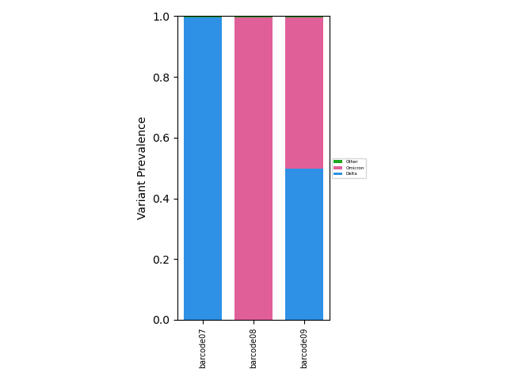

### VirStrain

Sample/s suspect for coinfection were run against a database containing representative SARS-CoV-2 sequences. The VirStrain result shows the possible lineage assignment for the sample/s.

| Sample | Most Possible Strain | Other Possible Strain |
| --- | --- | --- |
| barcode07 | AY.27_B.1.617.2 | C.36.3 |
| barcode08 | Omicron_BA.2 | Can not detect other strains. |
| barcode09 | Omicron_BA.2 | B.1.617.2 |

## Bammix flags for nucleotide mixture

The figure below shows the Bammix plot for nucleotide mixtures of the flagged sample/s. Multiple sites containing heterogenous bases crossing the threshold of >20% mixture will be apparent.

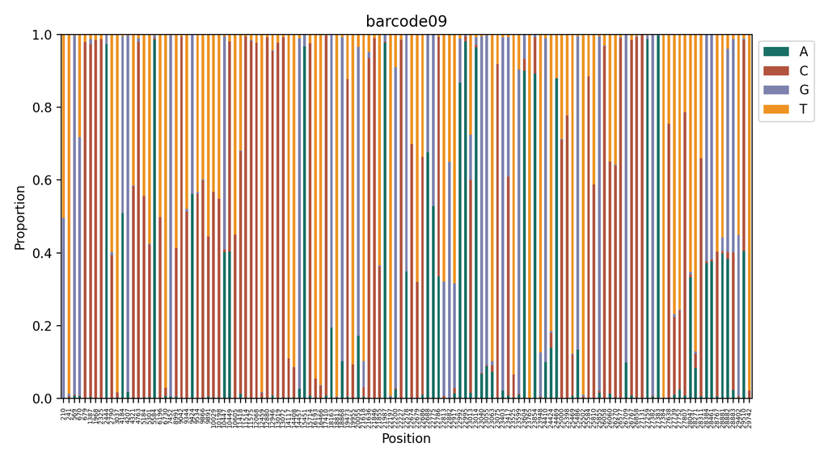

## Alternative allele fraction

### For each lineage-defining mutations

The alternative allele fraction (AAF) determines the number of reads supporting each variant detected in the sample/s. The AAF per mutation of sample/s flagged for SARS-CoV-2 coinfection are shown in the figure. Delta, Omicron, and shared mutations are represented by blue, pink, and purple, respectively.

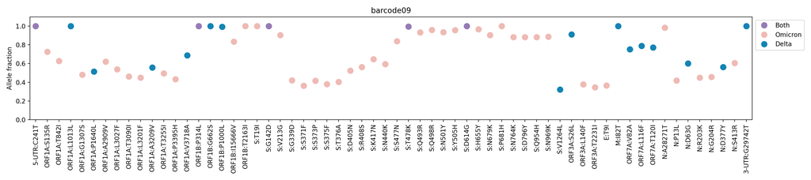

### For each amplicon

The AAF for each amplicon is plotted by getting the average allele fraction for Delta and Omicron defining mutation within the range of that amplicon.

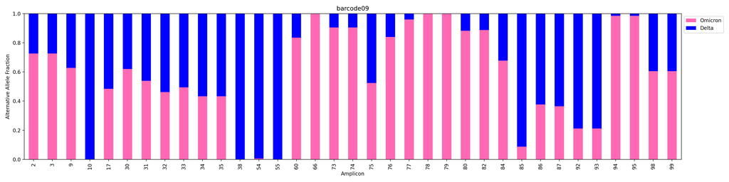

## References

### Pipeline

The tools used in this [pipeline](https://github.com/lanadelrea/CoPi) are as follows:

- [Pangolin](https://github.com/cov-lineages/pangolin)
- [Nextclade](https://github.com/nextstrain/nextclade)
- Freyja
- VirStrain
- [Bammix](https://github.com/chrisruis/bammix)
- Custom scripts adopted from Bolze et al.